# ggplot2 boxplots

Wendy Phillips

2023-03-11

One of the most used and most useful plotting methods is the boxplot. It provides a simple representation of the distribution of numerical data, either of a single group or multiple groups. Here, I will demonstrate how to make boxplots with *ggplot2*.

To begin, we load the ggplot library.

```r
library(ggplot2)
```

We will use one of the datasets that are available with the base R package *datasets*. This dataset has results from an experiment assessing the ability of eight different components of orchard sprays to repel honeybees. To find out more information about the dataset, type a `?` followed by the name of the dataset. In this case: `?OrchardSprays`. If you want to find out what other datasets are already available to you as a part of your currently installed packages, you can use the command `data()`.

To explicitly load the dataset into your environment, type this.

```r
data("OrchardSprays")
```

There are various ways to quickly explore the data set. Here are a couple.

```r
head(OrchardSprays)
```

```
##   decrease rowpos colpos treatment
## 1       57      1      1         D
## 2       95      2      1         E
## 3        8      3      1         B
## 4       69      4      1         H
## 5       92      5      1         G
## 6       90      6      1         F
```

```r
summary(OrchardSprays)
```

```
##     decrease          rowpos         colpos       treatment
##  Min.   :  2.00   Min.   :1.00   Min.   :1.00   A      : 8
##  1st Qu.: 12.75   1st Qu.:2.75   1st Qu.:2.75   B      : 8
##  Median : 41.00   Median :4.50   Median :4.50   C      : 8
##  Mean   : 45.42   Mean   :4.50   Mean   :4.50   D      : 8
##  3rd Qu.: 72.00   3rd Qu.:6.25   3rd Qu.:6.25   E      : 8
##  Max.   :130.00   Max.   :8.00   Max.   :8.00   F      : 8
##                                                 (Other):16
```

Before trying out the ggplot method, let’s look at how a boxplot looks using the base R *graphics* `boxplot()` command.

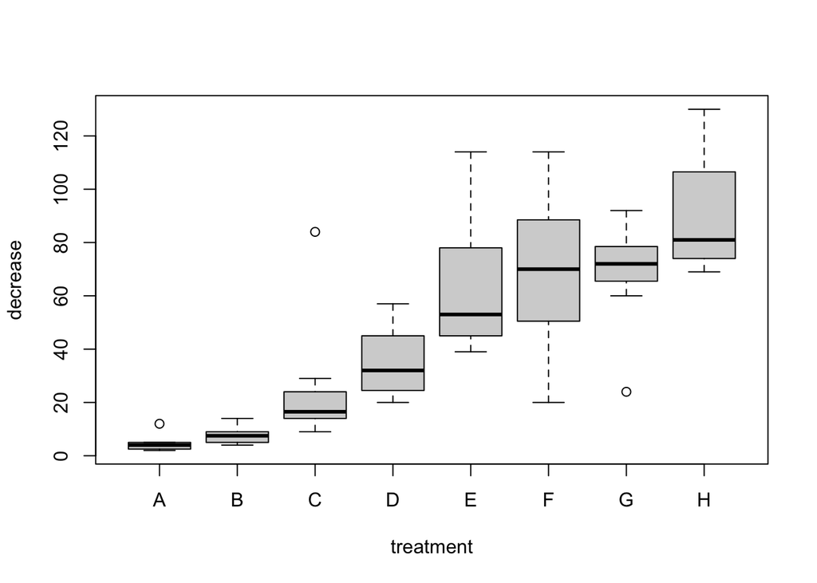

```r
boxplot(decrease ~ treatment, data = OrchardSprays)
```

That actually looks pretty good. And there are a variety of arguments we could use to customize the look of it. To find out more about those options, ask for help on the boxplot function with the command: `?boxplot`.

Now, let’s compare that to the most basic boxplot of the same data using ggplot2. We use the basic format for ggplot calls, in which we begin by telling ggplot the dataset to use followed by what columns of the dataset to use for the basic aesthetic (`aes`) parameters. In the case of the boxplot, we need to assign the continuous response variable (`decrease`) to the y-axis and the categorical variable (`treatment`) to the x-axis. With the `ggplot(OrchardSprays, aes(x = treatment, y = decrease))` command, we will have initiated a ggplot object. However, with just that information alone, ggplot does not know what we want to do with that data and so just creates an empty plot that has the indicated x and y axes.

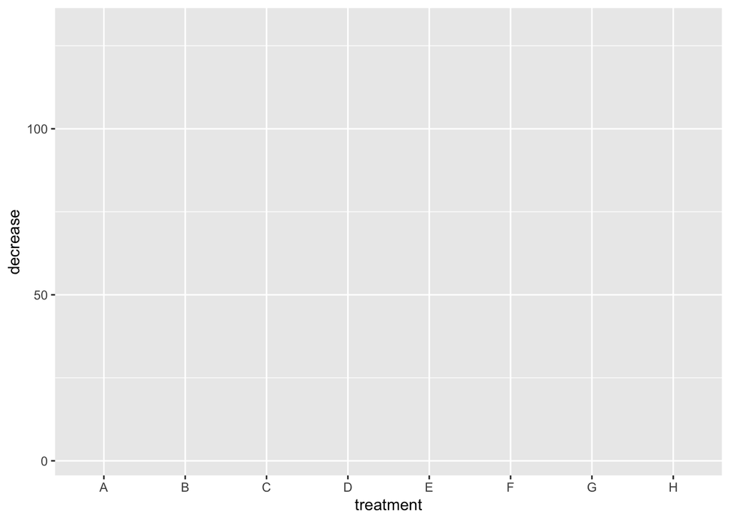

```r
ggplot(OrchardSprays, aes(x = treatment, y = decrease))
```

We must add the command `+ geom_boxplot()` to actually add a boxplot to the plotting object.

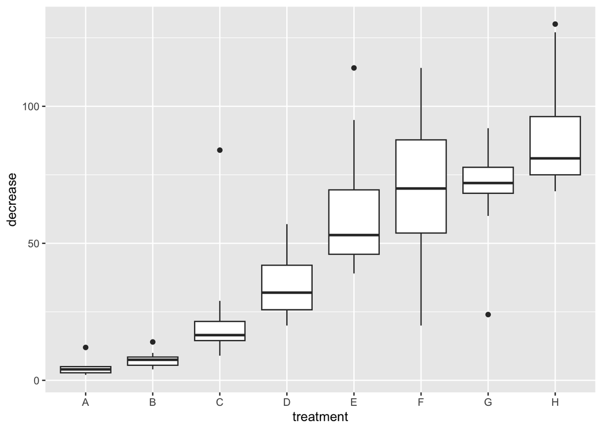

```r
ggplot(OrchardSprays, aes(x = treatment, y = decrease)) +
  geom_boxplot()
```

As you can see, the default theme of ggplot uses a grey background panel with white grid lines. What to do if you don’t like that style? The easiest way to change the overall theme is to use one of the other in-built ggplot themes, such as theme_classic used below specified by `theme_classic()`.

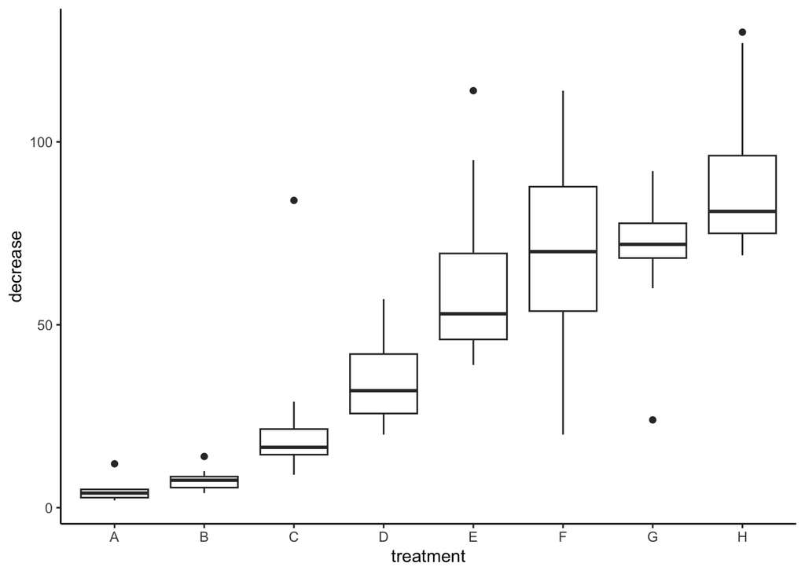

```r
ggplot(OrchardSprays, aes(x = treatment, y = decrease)) +
  geom_boxplot() +
  theme_classic()
```

We make the plot more visually appealing by adding to the initial aesthetic parameters that we would like a different color for each treatment using `color = treatment`.

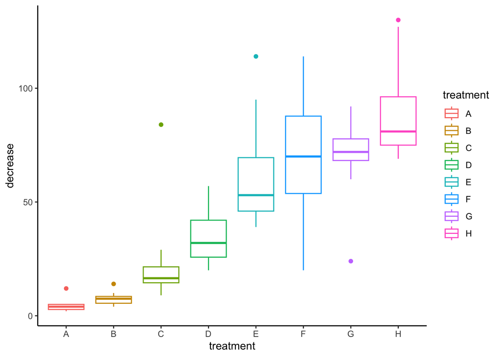

```r
ggplot(OrchardSprays, aes(x = treatment, y = decrease, color = treatment)) +
  geom_boxplot() +
  theme_classic()
```

We can add points on top of the boxplot to show each individual value of all data points with `geom_point()`.

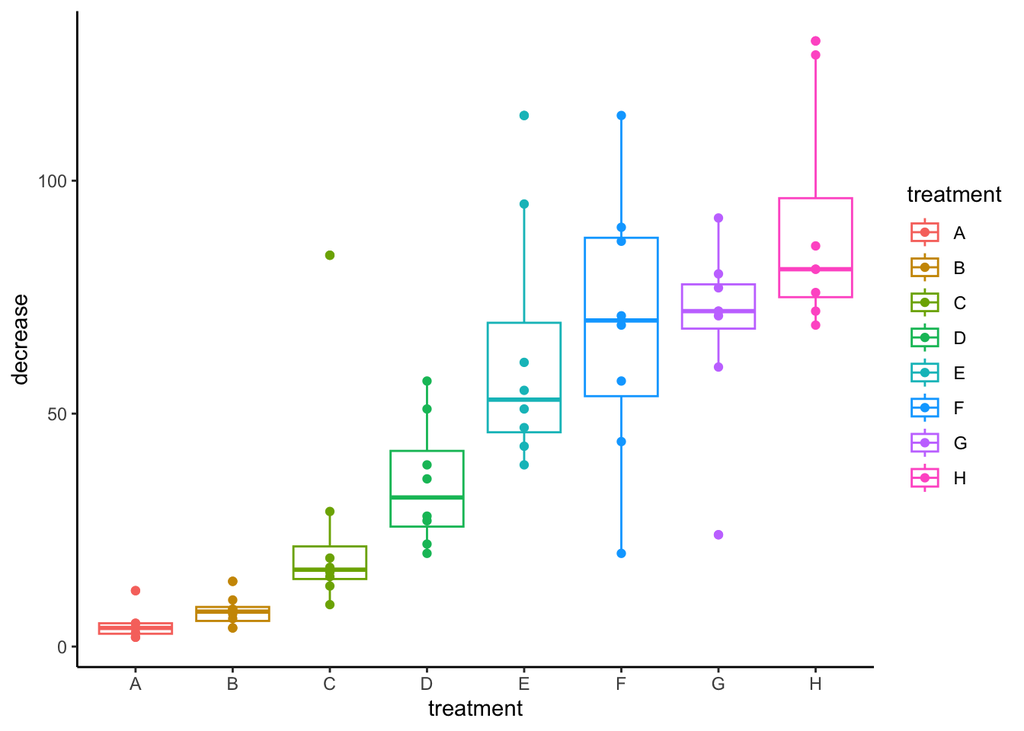

```r
ggplot(OrchardSprays, aes(x = treatment, y = decrease, color = treatment)) +
  geom_boxplot() +
  geom_point() +
  theme_classic()
```

Some of the points are overlapping each other. One way to separate them from each other is to offset them from the center by declaring their position to be set with jitter (`position = position_jitter()`. The default for `position_jitter` is to jitter both the width and the height. However, we don’t want to jitter the height in this case, as that would portray incorrect decrease values on the y-axis, so we set a parameter of `height = 0`.

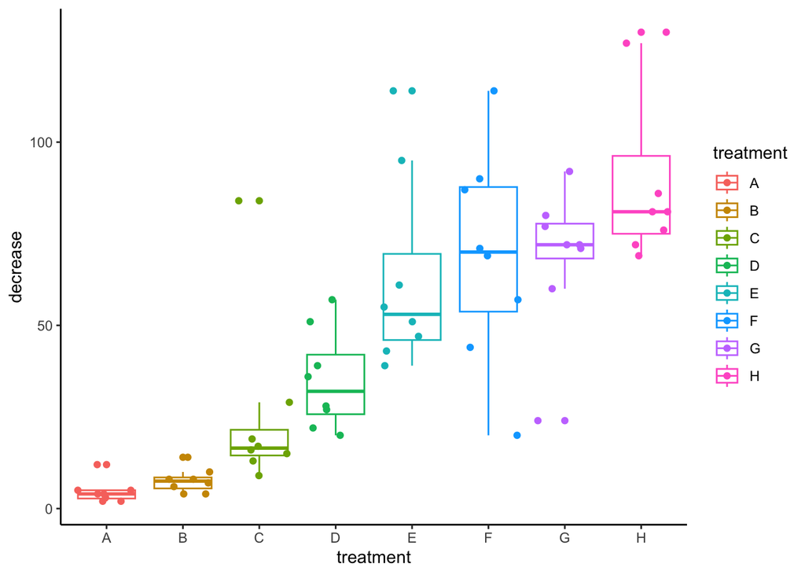

```r
ggplot(OrchardSprays, aes(x = treatment, y = decrease, color = treatment)) +
  geom_boxplot() +
  geom_point(position = position_jitter(height = 0)) +
  theme_classic()
```

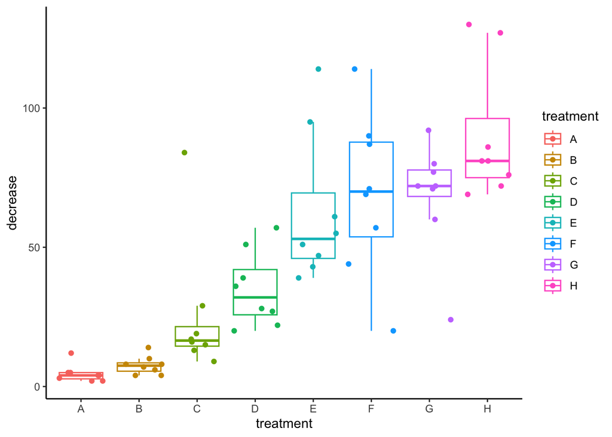

```r
ggplot(OrchardSprays, aes(x = treatment, y = decrease, color = treatment)) +
  geom_boxplot(outlier.colour = NA) +
  geom_point(position = position_jitter(height = 0)) +
  theme_classic()
```

I think the horizontal jitter on the points is too much as they go all the way to the edge of the boxes. So, I will set it to be a little less using `width = 0.2`.

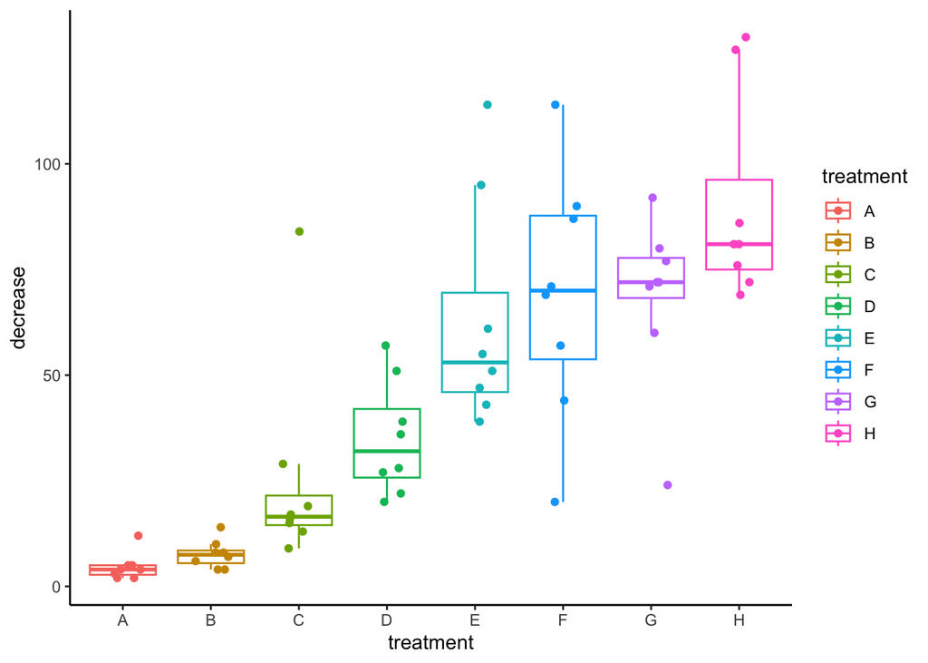

```r
ggplot(OrchardSprays, aes(x = treatment, y = decrease, color = treatment)) +
  geom_boxplot(outlier.colour = NA) +
  geom_point(position = position_jitter(height = 0, width = 0.2)) +
  theme_classic()
```

Let’s say I want to make the points bigger. That can be done by adding a size parameter (`size = 2`). But then I’m worried that they will overlap each other and be less discernible. So, I will change their transparency, by declaring an alpha value (between 0 and 1), such as `alpha = 0.6`.

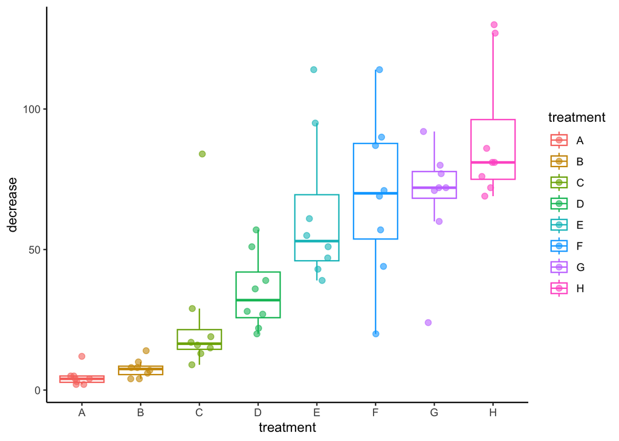

```r
ggplot(OrchardSprays, aes(x = treatment, y = decrease, color = treatment)) +
  geom_boxplot(outlier.colour = NA) +
  geom_point(position = position_jitter(height = 0, width = 0.2), size = 2, alpha = 0.6) +
  theme_classic()
```

Next, let’s change the axis labels so that they are capitalized by specifying `labs()` terms.

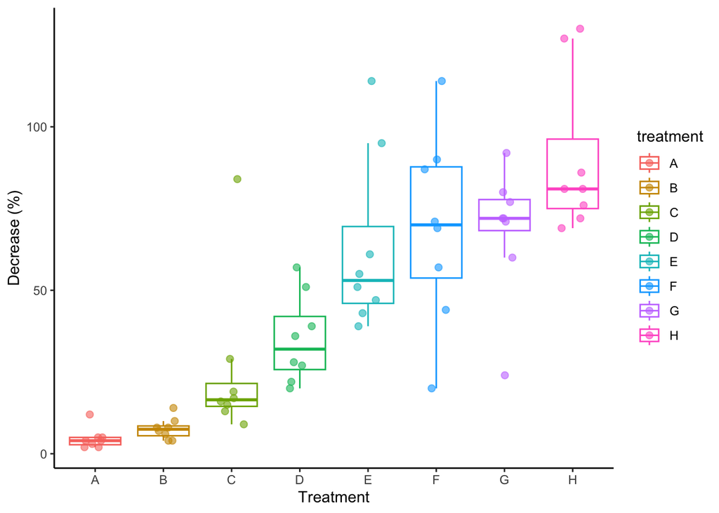

```r
ggplot(OrchardSprays, aes(x = treatment, y = decrease, color = treatment)) +
  geom_boxplot(outlier.colour = NA) +
  geom_point(position = position_jitter(height = 0, width = 0.2), size = 2, alpha = 0.6) +
  theme_classic() +
  labs(x = "Treatment", y = "Decrease (%)")
```

Adding a color aesthetic for the treatment group causes a legend for that aesthetic to appear. In this case, a legend isn’t necessary because the same information is shown on the x-axis. So, we can remove the legend to make it less busy. To do that, we bring in a new ggplot element: the theme function. In this case, we specify `theme(legend.position = "none")`. There are many, many ways to change aspects of the plot using the theme function. I’ll show just a few of them below.

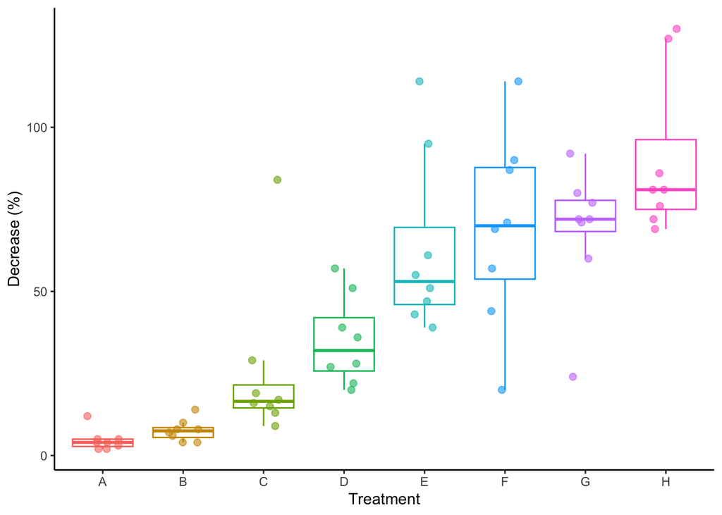

```r
ggplot(OrchardSprays, aes(x = treatment, y = decrease, color = treatment)) +
  geom_boxplot(outlier.colour = NA) +
  geom_point(position = position_jitter(height = 0, width = 0.2), size = 2, alpha = 0.6) +
  theme_classic() +
  labs(x = "Treatment", y = "Decrease (%)") +
  theme(legend.position = "none")
```

The legend.position theme used above took the value “none” as an argument. Other themes need to be assigned an element. There are four common elements: `element_text()`, `element_line()`, `element_rect()`, and `element_blank()`. (See https://ggplot2.tidyverse.org/reference/element.html) It is fairly self explanatory what type of elements the first three will add. The last one, element_blank(), is used to remove unwanted elements there by default.

One of the most common and basic changes to the plot we can apply through the theme function are font characteristics. Just as an example, we can make the axis titles bigger using `axis.title = element_text(size = 16)` .

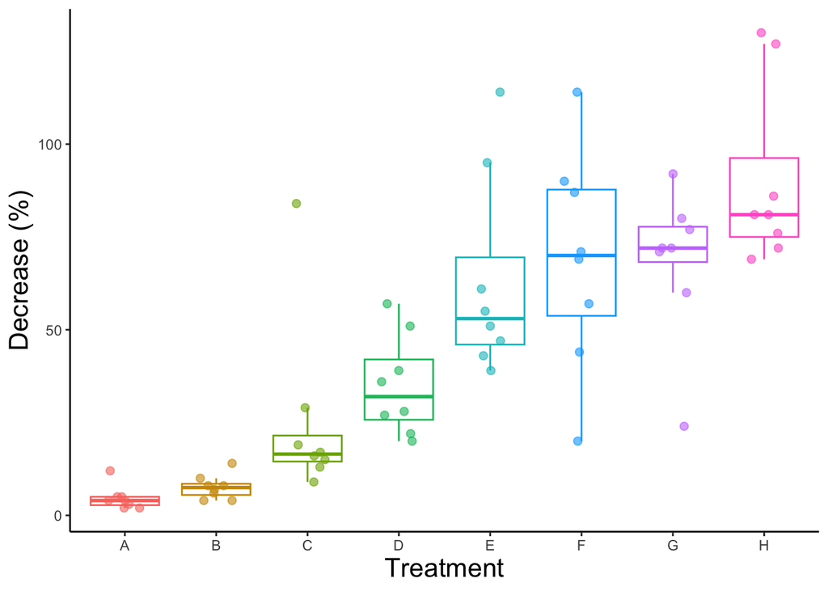

```r
ggplot(OrchardSprays, aes(x = treatment, y = decrease, color = treatment)) +
  geom_boxplot(outlier.colour = NA) +
  geom_point(position = position_jitter(height = 0, width = 0.2), size = 2, alpha = 0.6) +
  theme_classic() +
  labs(x = "Treatment", y = "Decrease (%)") +
  theme(legend.position = "none",
        axis.title = element_text(size = 16))
```

Or make the axis titles bigger and the axis labels bigger with `axis.title = element_text(size = 16)` and `axis.text = element_text(size = 14)`.

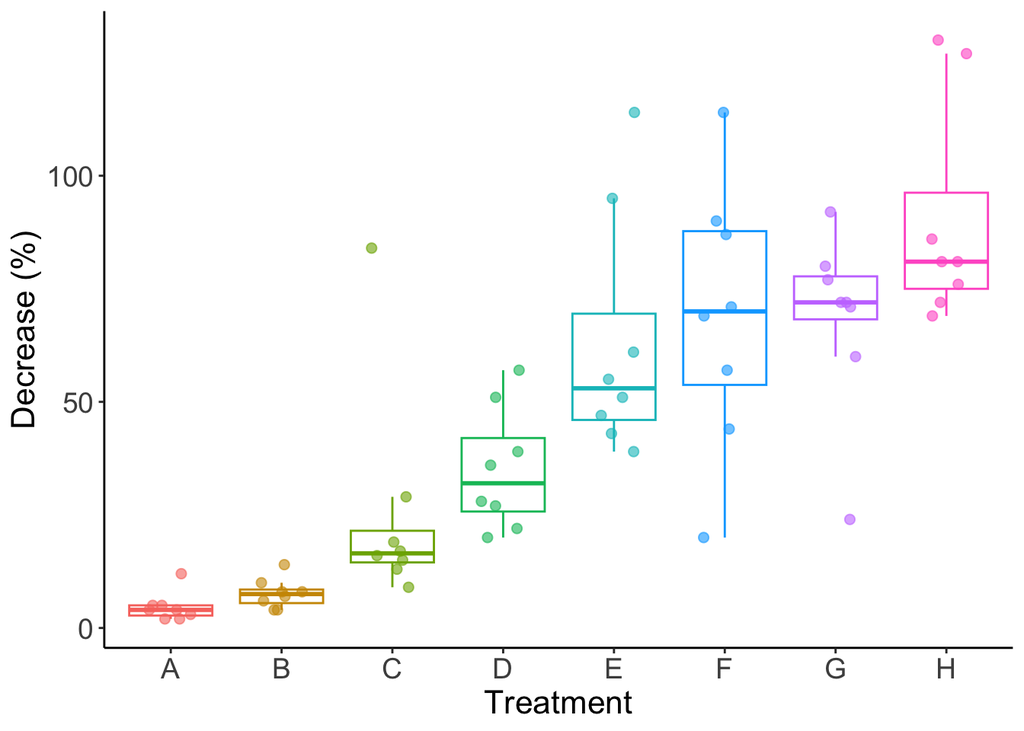

```r
ggplot(OrchardSprays, aes(x = treatment, y = decrease, color = treatment)) +
  geom_boxplot(outlier.colour = NA) +
  geom_point(position = position_jitter(height = 0, width = 0.2), size = 2, alpha = 0.6) +
  theme_classic() +
  labs(x = "Treatment", y = "Decrease (%)") +
  theme(legend.position = "none",
        axis.title = element_text(size = 16),
        axis.text = element_text(size = 14))
```

As you can see, theme_classic() does not include any grid lines. We can add y-axis lines to the plot with a theme addition `panel.grid.major.y = element_line()`.

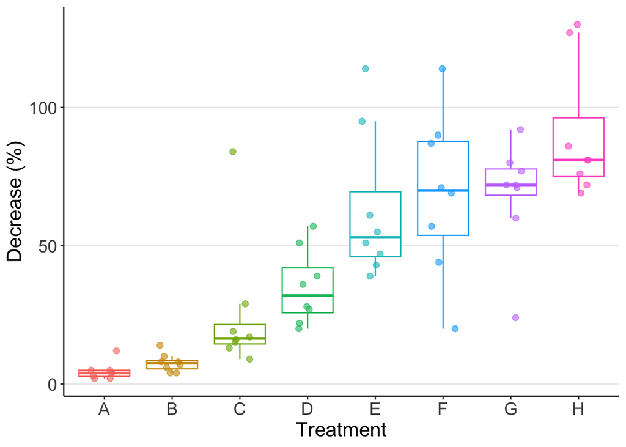

```r
ggplot(OrchardSprays, aes(x = treatment, y = decrease, color = treatment)) +
  geom_boxplot(outlier.colour = NA) +
  geom_point(position = position_jitter(height = 0, width = 0.2), size = 2, alpha = 0.6) +
  theme_classic() +
  labs(x = "Treatment", y = "Decrease (%)") +
  theme(legend.position = "none",
        axis.title = element_text(size = 16),
        axis.text = element_text(size = 14),
        panel.grid.major.y = element_line())
```

Maybe we don’t like having the tick marks on the x-axis. We can remove them by specifying the theme element `element_blank()`.

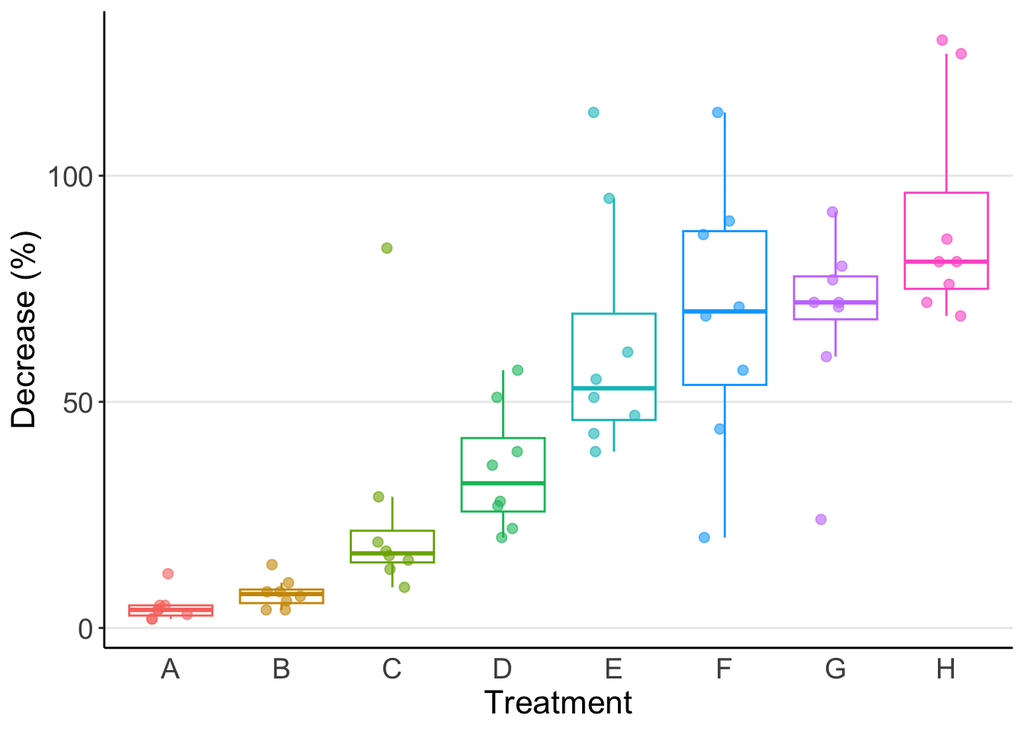

```r
ggplot(OrchardSprays, aes(x = treatment, y = decrease, color = treatment)) +
  geom_boxplot(outlier.colour = NA) +
  geom_point(position = position_jitter(height = 0, width = 0.2), size = 2, alpha = 0.6) +
  theme_classic() +
  labs(x = "Treatment", y = "Decrease (%)") +
  theme(legend.position = "none",
        axis.title = element_text(size = 16),
        axis.text = element_text(size = 14),
        panel.grid.major.y = element_line(),
        axis.ticks.x = element_blank()
        )
```

The last element not yet used is `element_rect()`. To demonstrate its use, we’ll add a rectangle border around the body of the plot. Note, if `fill - NA` is not added, the inside of the rectangle will be filled with white, and the inside of the plot will no longer be visible.

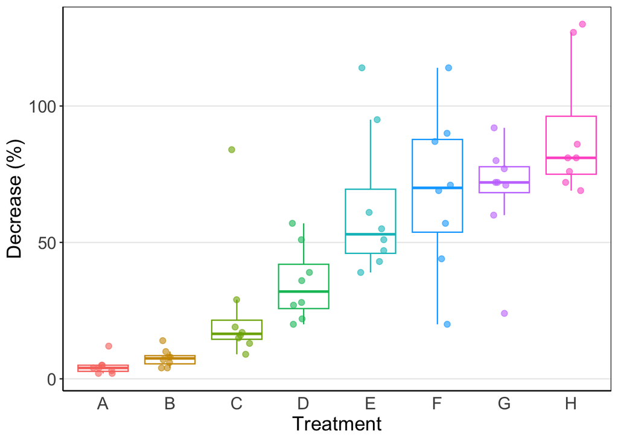

```r
ggplot(OrchardSprays, aes(x = treatment, y = decrease, color = treatment)) +
  geom_boxplot(outlier.colour = NA) +
  geom_point(position = position_jitter(height = 0, width = 0.2), size = 2, alpha = 0.6) +
  theme_classic() +
  labs(x = "Treatment", y = "Decrease (%)") +
  theme(legend.position = "none",
        axis.title = element_text(size = 16),
        axis.text = element_text(size = 14),
        panel.grid.major.y = element_line(),
        axis.ticks.x = element_blank(),
        panel.border = element_rect(fill = NA),
        )
```

Lastly, let’s say I didn’t like the default colors that ggplot uses. I can specify a different set of colors to use by declaring `scale_color_manual()` and providing a `values` parameter.

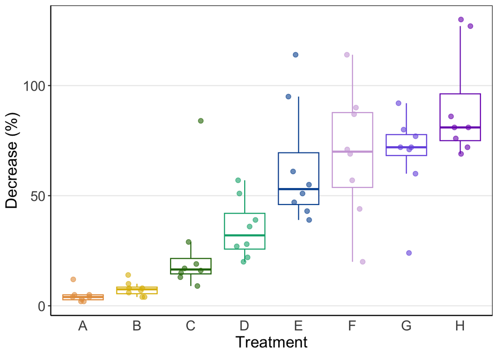

```r
ggplot(OrchardSprays, aes(x = treatment, y = decrease, color = treatment)) +
  geom_boxplot(outlier.colour = NA) +
  geom_point(position = position_jitter(height = 0, width = 0.2), size = 2, alpha = 0.6) +
  theme_classic() +
  labs(x = "Treatment", y = "Decrease (%)") +
  theme(legend.position = "none",
        axis.title = element_text(size = 16),
        axis.text = element_text(size = 14),
        panel.grid.major.y = element_line(),
        axis.ticks.x = element_blank(),
        panel.border = element_rect(fill = NA),
        ) +
  scale_color_manual(values = c("#e59c4a","#deba00","#277300","#01ac7b","#0154a0","#cea8da","#7659e1","#7c17bc"))
```